# Relatório ADSD - Projeto de medição

Arthur Emanuel, Arthur Vinícius e Victor Andrade

2 de julho de 2017

## O objetivo

Obter estatísticas que descrevam o comportamento do sistema “garupa.com” em contextos diferentes. E, dessa forma, encontrar pontos de melhoria no seu desempenho.

## Sobre os dados

Para que seja possível uma compreensão dos dados sem ter que voltar para o planejamento do projeto de medição, foram escolhidas as seguintes métricas sobre o método de filtragem de caronas da API Rest do sistema: tempo de rede, que é o tempo de tráfego da requisição e da resposta mais o tempo de autenticação; tempo de processamento, que é a duração do processamento no back-end depois que os dados já foram recuperados; e tempo de acesso ao banco de dados.

Além disso, apresentamos os seguintes 3 fatores, com seus respectivos níveis: quantidade de requisições feitas concorrentemente (1, 200); quantidade de caronas presentes no banco de dados (100, 1000); e quantidade de respostas a serem retornadas pela API (10, 100).

Vale salientar que o primeiro fator (quantidade de requsições feitas concorrentemente) não foi simulado de forma totalmente condizente com a realidade. Houve a limitação de que a coleta foi feita a partir de um único computador e, como consequência, não era possível fazer essa quantidade de requisições simultaneamente. Além disso, a API do sistema não aguenta 200 requisições ao mesmo tempo, devido ao framework utilizado. Por isso, foi mantida uma taxa constante de 64 requisições assíncronas enviadas em sequência.

```
## Source: local data frame [8 x 4]
## Groups: queries, results [?]
##
##   queries results rides repetitions
##     <int>   <int> <int>       <int>
## 1       1      10   100          50
## 2       1      10  1000          50
## 3       1     100   100          50
## 4       1     100  1000          50
## 5     200      10   100          50
## 6     200      10  1000          50
## 7     200     100   100          50
## 8     200     100  1000          50
```

## Elaboração dos Experimentos

Para cada uma das repetições mostradas na tabela acima, foi gerada aleatóriamente uma requisição de carona, que é composta de diversos atributos a serem filtrados. Em seguida, o banco de dados é limpo e repopulado com uma quantidade de cópias de uma carona que se adequa ao filtro igual ao fator correspondente ao experimento. O restante das caronas necessárias para preencher o banco são geradas aleatóriamente. Isso garante que o filtro escolhido ou as características das caronas não exerça influência muito forte sobre o resultado das medições.

Então, de modo a evitar que cofatores, como a quantidade de usuários acessando o servidor onde está hospedado o sistema ou o tráfego na rede local, distorcessem o resultados dos experimentos, todos foram executados sequencialmente e no mesmo dia a partir de um script.

Por fim, o resultado de cada experimento foi a média de cada uma das métricas definidas com relação às requisições feitas concorrentemente.

## Um olhar geral

Para termos uma ideia do desempenho do sistema de forma geral, pode-se calcular algumas estatísticas das variáveis escolhidas como métricas. Com isso, pode-se ter uma ideia do desempenho do sistema.

Abaixo estão as médias e seus respectivos desvios padrões de cada tempo de resposta:

1. Tempo de rede

```
## Mean: 7.212526
## Standard Deviation: 8.922302
```

2. Tempo de processamento

```
## Mean: 0.1861957
## Standard Deviation: 0.1196663
```

3. Tempo de banco de dados

```
## Mean: 0.03373354
## Standard Deviation: 0.02972722
```

Dessa forma, observa-se que o tempo de maior duração, em média, é o de rede. De posse desses dados, pode-se calcular o intervalo de confiança (com 95% de confiança) para cada uma das métricas:

1. Tempo de rede

```
##
##  One Sample t-test
##
## data:  d$net_time
## t = 16.167, df = 399, p-value < 2.2e-16
## alternative hypothesis: true mean is not equal to 0
## 95 percent confidence interval:
##  6.335496 8.089556
## sample estimates:
## mean of x
##  7.212526
```

2. Tempo de processamento

```
##
##  One Sample t-test
##
## data:  d$process_time
## t = 31.119, df = 399, p-value < 2.2e-16
## alternative hypothesis: true mean is not equal to 0
## 95 percent confidence interval:
##  0.1744330 0.1979585
## sample estimates:
## mean of x
## 0.1861957
```

3. Tempo de banco de dados

```
##
##  One Sample t-test
##
## data:  d$bd_time
## t = 22.695, df = 399, p-value < 2.2e-16
## alternative hypothesis: true mean is not equal to 0
## 95 percent confidence interval:
##  0.03081146 0.03665562
## sample estimates:
##  mean of x
## 0.03373354
```

# Um olhar por grupos

## Tempo de rede

Na sessão anterior, constatou-e, por meio da média e do intervalo de confiança, que o tempo de rede é o que aparenta ser mais custoso para o sistema. Essa métrica pode ter inúmeras variáveis que irão influenciar no seu valor. Portanto, para procurar por uma possível causa dentro do próprio sistema, pode-se observar as combinações dos fatores e procurar por alguma combinação de níveis de um fator x que resulte na mudança brusca de uma métrica y.

Para isso, agrupou-se os dados por combinação de fatores. Por exemplo, todos as observações que foram coletadas fazendo-se 200 requisições em conjunto, com 10 respostas esperadas e 1000 caroans criadas. E assim por diante.

Vale salientar que os grupos possuem um ID que foi criado para uma interpretação rápida sobre qual grupo está sendo visualizado. O ID consiste da concatenação dos níveis dos fatores. No exemplo dado acima, o grupo seria identificado por 200-10-1000.

Ao fim desse processo, obteve-se 8 grupos (todas as combinações possíveis). E, com isso, foi gerado um gráfico, no qual cada ponto representa a média de uma observação do grupo e cada margem de erro seu intervalo de confiança.

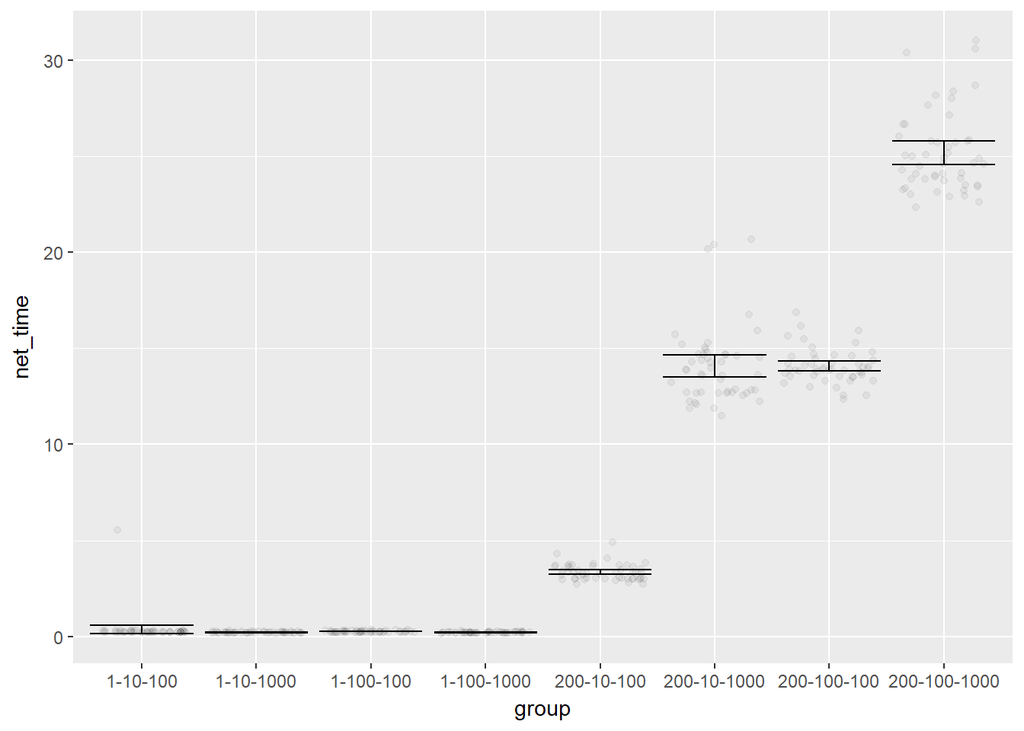

No entanto, é notório que o tempo de rede aumenta drásticamente quando o número de requisições aumenta, o que é esperado. Isso fica claro no gráfico quando os grupos com 200 requisições se distanciam consideravelmente dos grupos com apenas 1. Porém observa-se que o outros dois fatores também podem exercer alguma influência.

Uma característica comum a estes grupos é a grande quantidade de dados envolvida nas operações. O grupo 200-100-100 possui apenas 100 caronas criadas, porém espera que 100 sejam retornadas. O grupo 200-10-1000 requer apenas 10 caronas, porém existem 1000 caronas criadas. E, por fim, o grupo 200-100-1000 é o que possoui a maior quantidade de recursos, requer 100 respostas e possui 1000 caronas criadas.

Esses são indícios de que o tempo de rede está ligado tanto a quantidade de requisições feitas simultaneamente, quanto a quantidade de recursos envolvidos na operação, havendo um grau de interação entre esses fatores dado que um só se manifesta dependendo do valor do outro.

# Tempo de processamento

Vamos então à análise do tempo de processamento relacionado a cada combinação dos fatores. Utilizando-se dos mesmos grupos obtidos na análise anterior, foi gerado um gráfico para o tempo de processamento.

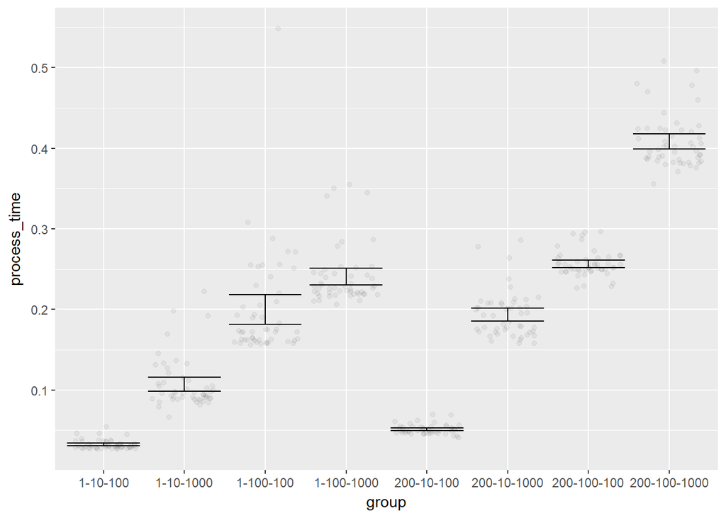

O gráfico gerado mostra que, independente do número de requisições em conjunto, os grupos que contém 10 respostas esperadas e 100 caronas existentes foram processados rapidamente (abaixo de 0.1 segundo), e seus respectivos intervalos de confiança indicam pouca variação nos dados.

Esse resultado inicial leva a crer que a quantidade de requisições em conjunto tem pouca influência no desempenho da operação, sendo os outros dois fatores decisivos para o tempo de processamento dos dados. Entretanto, enquanto a variação entre os dois grupos citados é pequena, em conjunto com outros fatores ela se potencializa, principalmente quando o número de elementos no banco é 1000.

Tem-se então indícios de que o tempo de processamento está ligado à quantidade de recursos envolvidos na operação, sendo a quantidade de respostas retornadas o principal motivo do aumento de tempo. Além disso, o número de requisições parece ter influência significativa apenas quando o número de caronas registradas é grande.

# Tempo de banco de dados

Por fim, analisa-se o tempo de banco de dados, seguindo o mesmo padrão das análises anteriores.

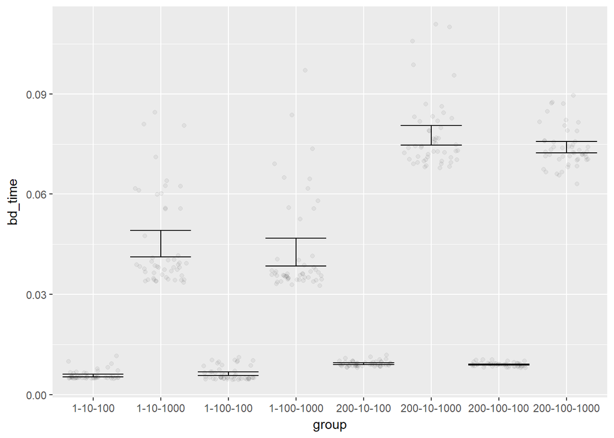

Como era de se esperar, por se tratar das operações no banco de dados do sistema, o desempenho dos grupos é fortemente influenciado pelo número de caronas existentes, sendo isso nítido no gráfico. Ao mesmo tempo, o número de resultados retornados não parece ter influência.

Tem-se então indícios de que o tempo de banco de dados está diretamente ligado à quantidade de elementos inseridos no banco de dados e mais fracamente ligado à quantidade de requisições feitas.

## Conclusão

Diante do exposto, foi observado que as métricas tempo de processamento e tempo de banco de dados se comportaram como o esperado. Estes tiveram respostas sempre abaixo de 1 segundo. Além disso, seu comportamento se mostrou como o esperado. Por exemplo: no banco de dados, quanto maior a quantidade de caronas criadas, maior a média de tempo de resposta. Todavia, é notório que a quantidade de requisições influencia demasiadamente o desempenho.

Ademais, o tempo de rede se comportou de uma forma totalmente inesperada. Com resultados que beiram os 30 segundos. Uma explicação plausível para essa catástrofe pode ser que a rede possui diversos fatores que estão além do escopo deste experimento. Como o tráfego em rede pode ser afetado pela quantidade de usuários usando-a simultaneamente em uma certa hora do dia, esse pode ser um fator não contemplado aqui, mas que pode ser testado em outro experimento. Outra fonte de demora pode ser o próprio servidor, já que o sistema está hospedado através de uma conta grátis, que pode ter seu desempenho restringido. Também não pode-se destacar que o framework utilizado não está se comportando bem com uma alta quantidade de requisições.